# Excess mortality

Weekly data

# STMF weekly data series

```r
download.file(url = "https://www.mortality.org/Public/STMF/Outputs/stmf.csv",
              destfile = "data-raw/mortality_org/stmf_week.csv",
              method = "curl")

zip(zipfile = "data-raw/mortality_org/stmf_week",
    files = "data-raw/mortality_org/stmf_week.csv")

file.remove("data-raw/mortality_org/stmf_week.csv")

download.file(url = "https://www.mortality.org/Public/STMF_DOC/STMFmetadata.pdf",
              destfile = "data-raw/mortality_org/STMFmetadata.pdf",
              method = "curl")

download.file(url = "https://www.mortality.org/Public/STMF_DOC/STMFNote.pdf",
              destfile = "data-raw/mortality_org/STMFNote.pdf",
              method = "curl")
```

## Weekly

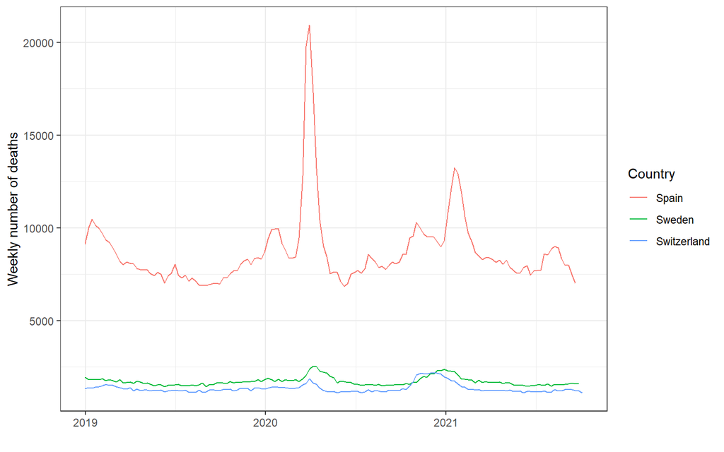

```r
stmf_week <- read_csv("data-raw/mortality_org/stmf_week.zip",
                      col_types = cols(Year = col_integer(),
                                       Week = col_integer(),
                                       Split = col_integer(),
                                       SplitSex = col_integer(),
                                       Forecast = col_integer()),
                      skip = 1) %>%
  filter(CountryCode %in% c("CHE", "ESP", "SWE")) %>%
  filter(Sex == "b") %>%
  select(CountryCode, Year, Week, DTotal) %>%
  rename(Deaths = DTotal) %>%
  mutate(Week2 = get_aweek(week = Week, year = Year,
                           start = "Monday", week_start = "Monday"),
         Week_start = get_date(week = Week, year = Year,
                               start = "Monday"),
         Deaths = as.integer(Deaths)) %>%
  relocate(Week2, Week_start, .after = Week) %>%
  mutate(Country = case_when(
    CountryCode == "CHE" ~ "Switzerland",
    CountryCode == "ESP" ~ "Spain",
    CountryCode == "SWE" ~ "Sweden"
  )) %>% select(-CountryCode) %>% relocate(Country)

write_rds(stmf_week, "data/mortality_org/stmf_week.Rds")
```

Switzerland & Sweden have slightly more data:

```r
stmf_week %>%
  filter(Year == 2021) %>%
  group_by(Country) %>%
  summarize(Max_week = max(Week))
```

```
# A tibble: 3 x 2
  Country     Max_week
  <chr>          <int>
1 Spain             38
2 Sweden            39
3 Switzerland       40
```

## Monthly

Weekly data converted to monthly using [weekToMonth](https://rdrr.io/cran/wktmo/man/weekToMonth.html) function from `wktmo` package.

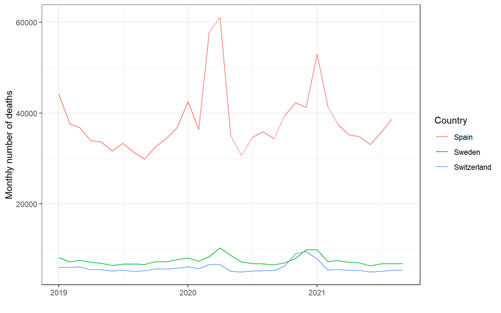

```r
stmf_month <- bind_rows(

  weekToMonth(stmf_week[stmf_week$Country == "Switzerland", ]$Deaths,
              datStart = "03-01-2000", wkMethod = "ISO") %>%
    as_tibble() %>%
    mutate(Country = "Switzerland"),

  weekToMonth(stmf_week[stmf_week$Country == "Spain", ]$Deaths,
              datStart = "03-01-2000", wkMethod = "ISO") %>%
    as_tibble() %>%
    mutate(Country = "Spain"),

  weekToMonth(stmf_week[stmf_week$Country == "Sweden", ]$Deaths,
              datStart = "03-01-2000", wkMethod = "ISO") %>%
    as_tibble() %>%
    mutate(Country = "Sweden")

) %>%
  separate(yearMonth, c("Year", "Month"), convert = TRUE) %>%
  rename(Deaths = value) %>%
  mutate(Date = ymd(paste0(Year, "-", Month, "-01")),
         Deaths = as.integer(Deaths)) %>%
  relocate(Country, Year, Month, Date)

write_rds(stmf_month, "data/mortality_org/stmf_month.Rds")
```

*Note: Only showing data till Aug 2021 for Spain (data is available only till week 38 which ends on `2021-09-26`). Data till Sept for Switzerland and Sweden.*  
## Yearly totals

Conversions are not perfect!

```r
differences <- left_join(
  stmf_week %>%
    filter(Year >= 2019) %>%
    group_by(Country, Year) %>%
    summarise(Weekly = round(sum(Deaths))) %>%
    ungroup(),

  stmf_month %>%
    filter(Year >= 2019) %>%
    group_by(Country, Year) %>%
    summarise(Monthly = round(sum(Deaths))) %>%
    ungroup()
) %>%
  mutate(Difference = Weekly - Monthly,
         Perc_weekly = percent((Weekly - Monthly) / Weekly, accuracy = 0.01))
```

Example of 2019-21 yearly totals derived from both original weekly & transformed monthly data illustrate this problem:

| Country | Year | Weekly | Monthly | Difference | Perc_weekly |
| --- | --- | --- | --- | --- | --- |
| Spain | 2019 | 414914 | 416090 | -1176 | -0.28% |
| Spain | 2020 | 497823 | 491345 | 6478 | 1.30% |
| Spain | 2021 | 333558 | 337544 | -3986 | -1.19% |
| Sweden | 2019 | 85936 | 86173 | -237 | -0.28% |
| Sweden | 2020 | 96950 | 95406 | 1544 | 1.59% |
| Sweden | 2021 | 65574 | 66586 | -1012 | -1.54% |
| Switzerland | 2019 | 67509 | 67688 | -179 | -0.27% |
| Switzerland | 2020 | 77196 | 75966 | 1230 | 1.59% |
| Switzerland | 2021 | 51320 | 52165 | -845 | -1.65% |

Showing small imperfections of the `week -> month` transition! 2020 seems to be always a bit in `+` and 2021 in `-`.

# BfS weekly data series for CHE

*Mortality, causes of death* chapter. [Overview of data](https://www.bfs.admin.ch/bfs/en/home/statistics/health/state-health/mortality-causes-death.html).

## Weekly number of deaths, 2010-2019

```r
download.file(url = "https://www.bfs.admin.ch/bfsstatic/dam/assets/12607335/master",
              destfile = "data-raw/BfS/ts-e-14.03.04.03-wr_ZR.csv",
              method = "curl")
```

Last five years with two age groups

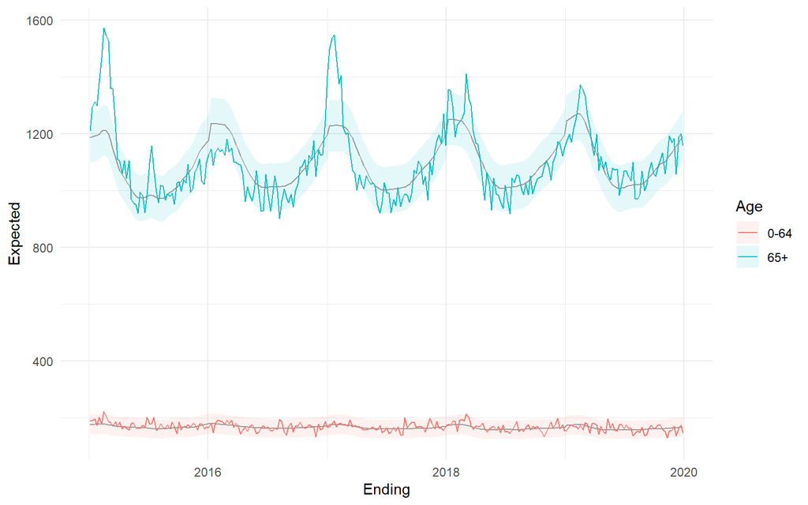

## Weekly number of deaths, 2020-2021

[Source](https://www.bfs.admin.ch/bfs/en/home/statistics/catalogues-databases/tables.assetdetail.19564278.html).

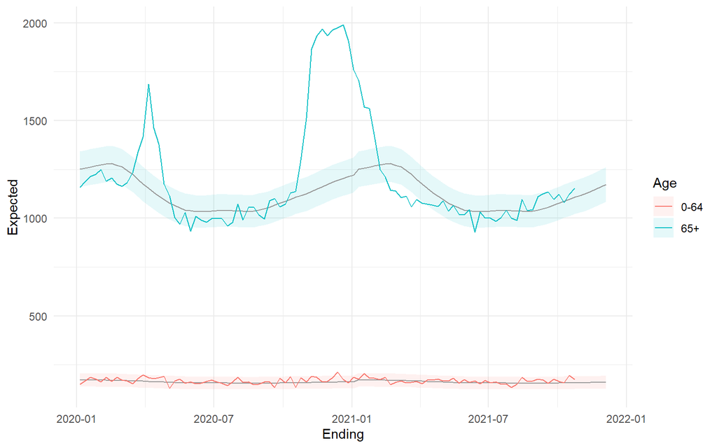

```r
download.file(url = "https://www.bfs.admin.ch/bfsstatic/dam/assets/19564278/master",
              destfile = "data-raw/BfS/ts-e-14.03.04.03-wr.csv",
              method = "curl")

zip(zipfile = "data-raw/BfS/ts-e-14.03.04.03-wr.zip",
    files = "data-raw/BfS/ts-e-14.03.04.03-wr.csv")

file.remove("data-raw/BfS/ts-e-14.03.04.03-wr.csv")
```

## Yearly totals of excess deaths

**2021 calculated untill week 25 (`2021-06-27`)**

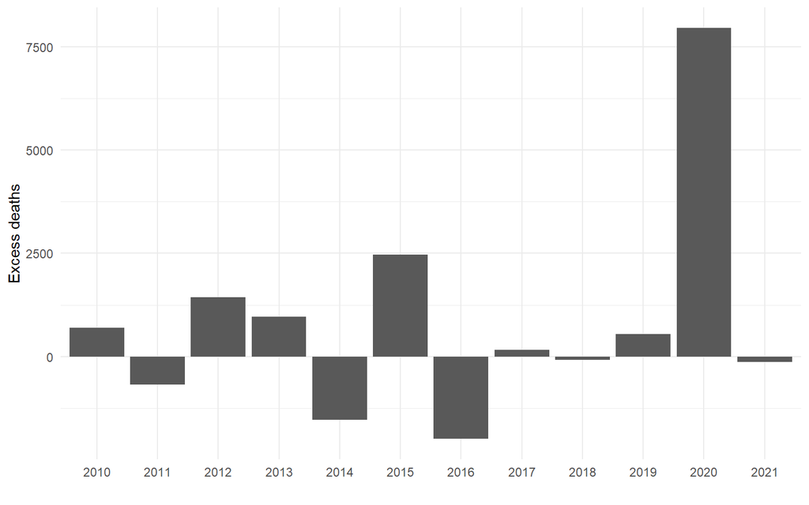

```r
excess_2010_2020 <- week_2010_2021 %>%
  filter(Ending <= as.Date("2021-06-27")) %>%
  mutate(Excess_expected = NumberOfDeaths - Expected) %>%
  # mutate(Excess_upperB = NumberOfDeaths - upperB) %>%
  # group_by(Year, Age) %>%
  group_by(Year) %>%
  summarise(Excess_expected = sum(Excess_expected)) %>%
  # summarise(Excess_upperB = sum(Excess_upperB)) %>%
  ungroup()

write_rds(excess_2010_2020, "data/BfS/excess_2010_2020.Rds")
```

# Comparing BfS to STMF

```r
bfs_stmf <- left_join(

  week_2010_2021 %>%
    filter(Ending <= as.Date("2021-05-23")) %>%
    group_by(Year, Week) %>%
    summarise(NumberOfDeaths = sum(NumberOfDeaths)) %>%
    ungroup(),

  stmf_week %>%
    filter(Country == "Switzerland")

) %>%
  mutate(diff = NumberOfDeaths - Deaths)
```

Some end of the year corrections (?):

## Absolute

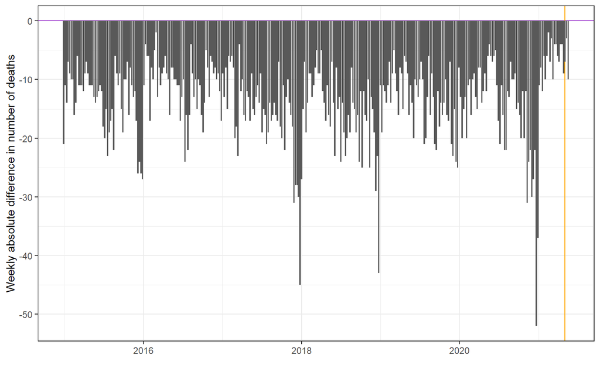

## Percentages

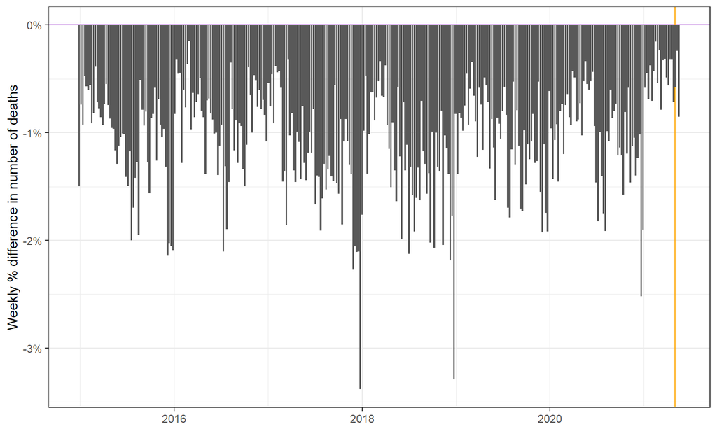

To cite R in publications use:

R Core Team (2021). *R: A Language and Environment for Statistical Computing*. R Foundation for Statistical Computing, Vienna, Austria. https://www.R-project.org/.

To cite the `ggplot2` package in publications use:

Wickham H (2016). *ggplot2: Elegant Graphics for Data Analysis*. Springer-Verlag New York. ISBN 978-3-319-24277-4, https://ggplot2.tidyverse.org.